# Simultaneous Directional Inference

2023-08-18

Supplementary R code for reproducing the examples in the paper ``Simultaneous Directional Inference’’.

## Set up

Install the latest version of the [`nplus`](https://github.com/aldosolari/nplus) R package:

```r
devtools::install_github("aldosolari/nplus")
```

## Introduction

We consider the problem of inference on the signs of $n>1$ parameters. Let $\theta = (\theta_1,\ldots,\theta_n)$ be a vector of $n$ unknown real-valued parameters. For any $I\subseteq \{1,\ldots,n\}$, let $n^+(I)$ and $n^-(I)$ be the number of parameters $\theta_i$, $i \in I$ with positive values and negative values, respectively:
$$n^+(I) = |\{ i \in I
: \theta_i > 0 \}|, \quad n^-(I) = |\{ i \in I : \theta_i < 0 \}|.$$
For simplicity of notation, we use $n^+$ and $n^-$ instead of $n^+(\{1,\ldots,n\})$ and $n^-(\{1,\ldots,n\})$.

Our first goal is to provide post-hoc lower bounds $\ell_{\alpha}^{+}(I)$ and $\ell_{\alpha}^{-}(I)$ for $n^+(I)$ and $n^-(I)$ such that
$$\mathrm{pr}_{\theta}\Big(
n^{+}(I)
\geq
\ell_{\alpha}^{+}(I),\,\,
n^{-}(I)
\geq
\ell_{\alpha}^{-}(I),
\mathrm{\,\,for\,\,all\,\,}I \Big) \geq 1- \alpha.$$
It is worth noting that once we have obtained the confidence lower bounds on the number of positive and negative parameters, we can automatically derive the corresponding upper bounds, i.e. if $n^{+}(I) \geq \ell_\alpha^+(I), n^{-}(I) \geq \ell_\alpha^-(I)$ holds, then also $n^{+}(I) \leq |I| - \ell^-_\alpha(I), n^{-}_\alpha(I) \leq |I| - \ell^{+}_\alpha(I)$ holds.

For finding $\ell_{\alpha}^{+}(I)$ and $\ell_{\alpha}^{-}(I)$, we use the *directional closed testing* (DCT) procedure: first, select from each pair
$$H_i^-: \theta_i \leq 0, \qquad
H_i^+: \theta_i \geq 0.$$

the hypothesis to test. Let $p_i$ and $q_i=1-p_i$ be the $p$-values for $H_i^-$ and $H_i^+$, respectively. We select $H_i^-$ if $p_i \leq 1/2$ and $H_i^+$ if $p_i > 1/2$.

Second, on the selected $n$ one-sided hypotheses, apply the closed testing procedure at level $\alpha$. Of course, the second step has to take care to adjust for the first step of selection from the same data.

In some settings it is enough to infer on positive and non-positive findings, i.e., the interest is only in lower bounds on $n^+(I)$ and on $n^-(I)+n^0( I)$, where $n^0( I) = | I|-n^+(I)-n^-(I) = |i\in I: \theta_i = 0|$. Thus we would like to provide lower bounds $\bar{\ell}_{\alpha}^{+}(I)$ and $\bar{\ell}_{\alpha}^{-}(I)$ for $n^+(I)$ and $n^-(I)+n^0(I)$ such that
$$\mathrm{pr}_{\theta}\Big(
n^{+}(I)
\geq
\bar{\ell}_{\alpha}^{+}(I),\,\,
n^{-}(I)+n^{0}(I)
\geq
\bar{\ell}_{\alpha}^{-}(I),
\mathrm{\,\,for\,\,all\,\,}I \Big) \geq 1- \alpha.$$
So the hypotheses considered for $i=1,\ldots,n$ are:
$$H_i^-: \theta_i \leq 0, \quad K_i: \theta_i > 0, \quad i=1,\ldots,n.$$
Exactly one of the hypotheses pairs is true. For finding $\bar{\ell}_{\alpha}^+(I)$ and $\bar{\ell}_{\alpha}^-(I)$ we use the *partitioning principle* to the $2^n$ orthants defined by $\theta_i \in \{(-\infty,0],(0,\infty)\}, i=1,\ldots, n$. Heller & Solari (2023) showed that the bounds obtained through the *adaptive local tests* with partitioning principle (AP) uniformly improves upon the DCT bounds: $\bar{\ell}_{\alpha}^{+}(I)\geq \ell_{\alpha}^{+}(I)$, $\bar{\ell}_{\alpha}^{-}(I)\geq \ell_{\alpha}^{-}(I)$.

Heller, R. and Solari, A. (2022). Simultaneous directional inference. arXiv preprint arXiv:2301.01653

## Subgroup Analysis

The data analysed in Gail and Simon (1985) consists of the difference in disease-free survival probabilities at 3 years for breast cancer patients who underwent a PFT treatment compared to those who received a PF treatment. The study includes a total of 1260 patients divided in $n=4$ subgroups, classified based on age and progesterone receptor levels. Table 2 in Gail and Simon (1985) reports the Kaplan-Meier estimate $\hat{\pi}_{ij}$ of the disease-free survival probability at 3 years for patients who underwent treatment $j$ and belong to subgroup $i$, along with the corresponding standard error $\mathrm{SE}(\hat{\pi}_{ij})$, calculated using Greenwood’s formula.

The Kaplan-Meier estimate of survival probability at 3 years (and standard error SE) for patients in subgroup $i$ receiving treatment PFT or PF.

| Subgroup i | PFT | SE(PFT) | PF | SE(PF) |
| --- | --- | --- | --- | --- |
| 1 | 0.599 | 0.0542 | 0.436 | 0.0572 |
| 2 | 0.526 | 0.0510 | 0.639 | 0.0463 |
| 3 | 0.651 | 0.0431 | 0.698 | 0.0438 |
| 4 | 0.639 | 0.0386 | 0.790 | 0.0387 |

```r
pi_1 = c(.599,  .526,  .651,  .639)
pi_2 = c(.436, .639, .698, .790)
SE_1 = c(.0542,  .0510,  .0431,  .0386 )
SE_2 = c(.0572,  .0463,  .0438,  .0387)
m1_tilde = (pi_1*(1-pi_1))/(SE_1^2)
m2_tilde = (pi_2*(1-pi_2))/(SE_2^2)
thetaHat = (asin(sqrt(pi_1)) - asin(sqrt(pi_2)))/sqrt( 1/(4*m1_tilde) + 1/(4*m2_tilde) )
round(thetaHat,3)
```

```
#> [1]  2.051 -1.635 -0.764 -2.708
```

```r
p_right_tail = 1-pnorm(thetaHat)
round(p_right_tail,4)
```

```
#> [1] 0.0202 0.9490 0.7774 0.9966
```

Based on the $p$-values $p_i$, we select the hypotheses $H_1^-$, $H_2^+$, $H_3^+$, $H_4^+$ and we adjust for the selection the corresponding $p$-values:

```r
n = length(p_right_tail)
S = rep("+",n)
S[p_right_tail <= 0.5] <- "-"
hyp_selected <- paste0("H",paste0(1:n,S))
p_selected <- 2*pmin(p_right_tail, 1-p_right_tail)
names(p_selected) <- hyp_selected
round(p_selected,4)
```

```
#>    H1-    H2+    H3+    H4+
#> 0.0403 0.1020 0.4451 0.0068
```

Function to compute the power set of a set:

```r
powset <- function(set) {
  n <- length(set)
  masks <- 2^(1:n-1)
  lapply( 1:2^n-1, function(u) set[ bitwAnd(u, masks) != 0 ] )
}
```

Function to compute the $p$-value of the Simes local test:

```r
p_combi_test <- function(x) {  min(sort(x)*length(x)/(1:length(x)))  }
```

Computing the $p$-value for each intersection hypothesis by using the Simes local test:

```r
res = unlist(
  lapply(powset(1:n), function(x) p_combi_test(p_selected[x]))
)
names(res) <- powset(hyp_selected)
round(res,4)
                 character(0)                           H1-
                          Inf                        0.0403
                          H2+               c("H1-", "H2+")
                       0.1020                        0.0806
                          H3+               c("H1-", "H3+")
                       0.4451                        0.0806
              c("H2+", "H3+")        c("H1-", "H2+", "H3+")
                       0.2039                        0.1209
                          H4+               c("H1-", "H4+")
                       0.0068                        0.0135
              c("H2+", "H4+")        c("H1-", "H2+", "H4+")
                       0.0135                        0.0203
              c("H3+", "H4+")        c("H1-", "H3+", "H4+")
                       0.0135                        0.0203
       c("H2+", "H3+", "H4+") c("H1-", "H2+", "H3+", "H4+")
                       0.0203                        0.0271
```

Adjusted $p$-values by closed testing:

```r
res_ct = res
closure = powset(1:n)
for (k in 1:length(closure))
res_ct[[k]] = max(res[sapply(1:length(closure), function(i) all(closure[[k]] %in% closure[[i]]))])
round(res_ct,4)
```

```
#>                  character(0)                           H1-
#>                           Inf                        0.1209
#>                           H2+               c("H1-", "H2+")
#>                        0.2039                        0.1209
#>                           H3+               c("H1-", "H3+")
#>                        0.4451                        0.1209
#>               c("H2+", "H3+")        c("H1-", "H2+", "H3+")
#>                        0.2039                        0.1209
#>                           H4+               c("H1-", "H4+")
#>                        0.0271                        0.0271
#>               c("H2+", "H4+")        c("H1-", "H2+", "H4+")
#>                        0.0271                        0.0271
#>               c("H3+", "H4+")        c("H1-", "H3+", "H4+")
#>                        0.0271                        0.0271
#>        c("H2+", "H3+", "H4+") c("H1-", "H2+", "H3+", "H4+")
#>                        0.0271                        0.0271
```

Partitioning procedure with adaptive tests:

```r
Sc = rep("-",n)
Sc[p_right_tail <= 0.5] <- "+"
hyp_part <- powset(1:n)
for (i in 1:length(hyp_part)){
hyp_part[[i]] <- Sc
hyp_part[[i]][ powset(1:n)[[i]] ] <- S[ powset(1:n)[[i]] ]
}
res_part <- res
names(res_part) <- hyp_part
round(res_part,4)
```

```
#> c("+", "-", "-", "-") c("-", "-", "-", "-") c("+", "+", "-", "-")
#>                   Inf                0.0403                0.1020
#> c("-", "+", "-", "-") c("+", "-", "+", "-") c("-", "-", "+", "-")
#>                0.0806                0.4451                0.0806
#> c("+", "+", "+", "-") c("-", "+", "+", "-") c("+", "-", "-", "+")
#>                0.2039                0.1209                0.0068
#> c("-", "-", "-", "+") c("+", "+", "-", "+") c("-", "+", "-", "+")
#>                0.0135                0.0135                0.0203
#> c("+", "-", "+", "+") c("-", "-", "+", "+") c("+", "+", "+", "+")
#>                0.0135                0.0203                0.0203
#> c("-", "+", "+", "+")
#>                0.0271
```

$95\%$ confidence lower and upper bounds $\bar{\ell}_{\alpha}^{+}$ and $n - \bar{\ell}_{\alpha}^{-}$ for $n^+$ by using the partitioning procedure with adaptive Simes’ tests:

```r
library(nplus)
nplus_bound(p_right_tail, alpha=0.05, method="Simes")
```

```
#> $lo
#> [1] 1
#>
#> $up
#> [1] 3
```

Index set of positive discoveries (i.e. $i:\theta_i >0$) and non-positive discoveries ($i:\theta_i \leq 0$) with familywise error rate control at level $\alpha$:

```r
nplus_fwer(p_right_tail, alpha=0.05, method="Simes")
```

```
#> $positive
#> integer(0)
#>
#> $nonpositive
#> [1] 4
```

Gail, M. and Simon, R. (1985). Testing for qualitative interactions between treatment effects and patient subsets. Biometrics, pages 361–372.

## Testing for qualitative interactions with follow-up inference

If testing for mixed signs of the parameter vector $\theta$ is of primary concern, DCT is applied only if the hypothesis of no qualitative interaction, $H_0:\{n^+=0\}\cup\{ n^−=0\}$, is rejected.

```r
res_qi = res
powset_ix = powset(1:n)
p_Sminus =res[sapply(1:length(powset_ix), function(i) identical(which(S=="-") , unlist(powset_ix[i])))]
p_Splus =res[sapply(1:length(powset_ix), function(i) identical(which(S=="+") , unlist(powset_ix[i])))]
p_H0 = max(p_Sminus,p_Splus)
round(p_H0,4)
```

```
#> [1] 0.0403
```

```r
res_qi[sapply(1:length(powset_ix), function(i) all(which(S=="+") %in% unlist(powset_ix[i])))] <- p_H0
res_qi[sapply(1:length(powset_ix), function(i) all(which(S=="-") %in% unlist(powset_ix[i])))] <- p_H0
round(res_qi,4)
```

```
#>                  character(0)                           H1-
#>                           Inf                        0.0403
#>                           H2+               c("H1-", "H2+")
#>                        0.1020                        0.0403
#>                           H3+               c("H1-", "H3+")
#>                        0.4451                        0.0403
#>               c("H2+", "H3+")        c("H1-", "H2+", "H3+")
#>                        0.2039                        0.0403
#>                           H4+               c("H1-", "H4+")
#>                        0.0068                        0.0403
#>               c("H2+", "H4+")        c("H1-", "H2+", "H4+")
#>                        0.0135                        0.0403
#>               c("H3+", "H4+")        c("H1-", "H3+", "H4+")
#>                        0.0135                        0.0403
#>        c("H2+", "H3+", "H4+") c("H1-", "H2+", "H3+", "H4+")
#>                        0.0403                        0.0403
```

```r
res_qi_ct <- res_qi
for (k in 1:length(closure))
res_qi_ct[[k]] = max(res_qi_ct[sapply(1:length(closure), function(i) all(closure[[k]] %in% closure[[i]]))])
round(res_qi_ct,4)
```

```
#>                  character(0)                           H1-
#>                           Inf                        0.0403
#>                           H2+               c("H1-", "H2+")
#>                        0.2039                        0.0403
#>                           H3+               c("H1-", "H3+")
#>                        0.4451                        0.0403
#>               c("H2+", "H3+")        c("H1-", "H2+", "H3+")
#>                        0.2039                        0.0403
#>                           H4+               c("H1-", "H4+")
#>                        0.0403                        0.0403
#>               c("H2+", "H4+")        c("H1-", "H2+", "H4+")
#>                        0.0403                        0.0403
#>               c("H3+", "H4+")        c("H1-", "H3+", "H4+")
#>                        0.0403                        0.0403
#>        c("H2+", "H3+", "H4+") c("H1-", "H2+", "H3+", "H4+")
#>                        0.0403                        0.0403
```

## Enhancing meta-analysis

We consider the data in Konstantopoulos (2011), where the effect of a modified school calendar (with more frequent but shorter breaks) on student achievement is examined. The meta-analysis uses studies of $n=56$ schools in 11 districts. The experimental design is a two-group comparison (modified calendar vs traditional calendar) which involves computing the standardized mean difference $X_i \sim N(\theta_i,1)$, where $\theta_i>0$ indicates a positive effects, i.e. a higher level of achievement in the group following the modified school calendar.

We analyze the data by providing the lower and upper bounds on the number of studies with positive effect in all schools and in the (data-driven) top $k$ schools.

Importing data from the R package `metafor`:

```r
require("metafor") || install.packages("metafor")
```

```r
dat <- get(data(dat.konstantopoulos2011))
x <- as.vector(dat$yi / sqrt(dat$vi))
n <- length(x)
p_right_tail <- pnorm(x, lower.tail = FALSE)
```

Partitioning procedure with adaptive tests (P) and directional closed testing (DCT) procedures: $(1-\alpha)=95\%$ confidence bounds [`LO+`,`UP+`] on the number of studies with positive effects along with the number of positive discoveries (`D+`) and $95\%$ confidence bounds [`LO-`,`UP-`] on the number of studies with nonpositive/negative effects along with the number of nonpositive/negative discoveries (`D-`) for different combining functions: Fisher, Simes, modified Simes and adaptive LRT:

```r
alpha = 0.05
S_minus = which(p_right_tail <= 0.5)
S_plus = which(p_right_tail > 0.5)
RES = matrix(NA, ncol=8, nrow=8)
RES[,1] = rep(c("Fisher","Simes","ASimes","ALRT"),each=2)
RES[,2] = rep(c("P","DCT"),4)
colnames(RES) <- c("Local test","Procedure", "LO+","UP+","D+", "LO-","UP-","D-")
for (i in 1:4){
 res_bound <- nplus_bound(p_right_tail, method=RES[2*i,1], alpha=alpha)
 res_d <- nplus_fwer(p_right_tail, method=RES[2*i,1], alpha=alpha)
 res_dct_lo <- min(which(nplus_pvalue(p_right_tail, method=RES[2*i,1], ix = S_minus) > alpha)) - 1
 res_dct_up <- n - (length(S_plus) - max(which(nplus_pvalue(p_right_tail, method=RES[2*i,1], ix = S_plus) > alpha)) + 1)
 RES[(2*i)-1,3] <- res_bound$lo
 RES[2*i,3] <- res_dct_lo
 RES[(2*i)-1,4] <- res_bound$up
 RES[2*i,4] <- res_dct_up
 RES[(2*i)-1,5] <- RES[2*i,5] <- length(res_d$positive)
 RES[(2*i)-1,6] <- n-res_bound$up
 RES[2*i,6] <- n - res_dct_up
 RES[(2*i)-1,7] <- n-res_bound$lo
 RES[2*i,7] <- n - res_dct_lo
 RES[(2*i)-1,8] <- RES[2*i,8] <- length(res_d$nonpositive)
}
knitr::kable(RES)
```

| Local test | Procedure | LO+ | UP+ | D+ | LO- | UP- | D- |
| --- | --- | --- | --- | --- | --- | --- | --- |
| Fisher | P | 10 | 53 | 4 | 3 | 46 | 0 |
| Fisher | DCT | 9 | 56 | 4 | 0 | 47 | 0 |
| Simes | P | 8 | 55 | 8 | 1 | 48 | 0 |
| Simes | DCT | 8 | 56 | 8 | 0 | 48 | 0 |
| ASimes | P | 8 | 54 | 8 | 2 | 48 | 0 |
| ASimes | DCT | 8 | 56 | 8 | 0 | 48 | 0 |
| ALRT | P | 11 | 53 | 5 | 3 | 45 | 0 |
| ALRT | DCT | 9 | 55 | 5 | 1 | 47 | 0 |

Discoveries by Guo and Romano (2015) procedures with FWER and FDR control at $\alpha=0.05$ level:

```r
GuoRomano2015 <- function(p_right_tail, alpha=0.05){

  p <- p_right_tail
  n <- length(p)
  sp <- sort( c(p,1-p), index.return=TRUE )

  FWER_id <- max(which(cumsum( sp$x <= alpha / (n - 1:n + 1L + alpha) )==1:(2*n)))
  FWER_REJ <- rep(FALSE,2*n)
  if (is.finite(FWER_id)) FWER_REJ[1:FWER_id] <- TRUE
  FWER_NONPOS <-  1:n %in% sp$ix[FWER_REJ]
  FWER_POS <-  (n+1):(2*n) %in% sp$ix[FWER_REJ]

  FDR_id <- max(which(sp$x <= alpha * (1:n) / n))
  FDR_REJ <- rep(FALSE,2*n)
  if (is.finite(FDR_id)) FDR_REJ[1:FDR_id] <- TRUE
  FDR_NONPOS <-  1:n %in% sp$ix[FDR_REJ]
  FDR_POS <-  (n+1):(2*n) %in% sp$ix[FDR_REJ]

  return(list(FWER = list(n_discoveries_positive = sum(FWER_NONPOS), n_discoveries_nonpositive = sum(FWER_POS)),
              FDR= list(n_discoveries_positive = sum(FDR_NONPOS), n_discoveries_nonpositive = sum(FDR_POS))))

}
GuoRomano2015(p_right_tail, alpha = alpha)
```

```
#> $FWER
#> $FWER$n_discoveries_positive
#> [1] 8
#>
#> $FWER$n_discoveries_nonpositive
#> [1] 1
#>
#>
#> $FDR
#> $FDR$n_discoveries_positive
#> [1] 12
#>
#> $FDR$n_discoveries_nonpositive
#> [1] 4
```

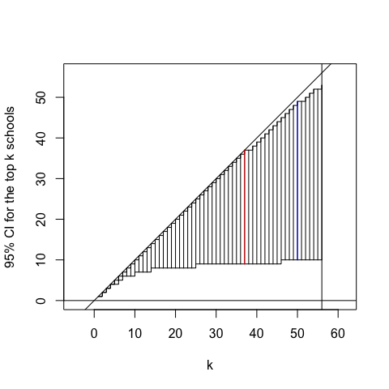

```r
ix_best <- sort(pmin(p_right_tail,1-p_right_tail), index.return=TRUE)$ix
bestk <- sapply(1:n, function(i)
  range(which( nplus_pvalue(p_right_tail, method = "Fisher", ix = ix_best[1:i]) > 0.05)) -1
)
plot(asp=1, type="s", ylim=c(0,n),xlim=c(1,n),
     bestk[2,], xlab="k", ylab="95% CI for the top k schools")
lines(bestk[1,],type="s")
abline(h=0)
abline(a=0,b=1)
abline(v=n)
for  (i in 1:n){
  segments(x0=i,x1=i,y0=bestk[1,i], y1=bestk[2,i])
}
segments(x0=37,x1=37,y0=bestk[1,37], y1=bestk[2,37], col="red")
segments(x0=50,x1=50,y0=bestk[1,50], y1=bestk[2,50], col="blue")
```

Konstantopoulos, S. (2011). Fixed effects and variance components estimation in three-level meta-analysis. Research Synthesis Methods, 2(1):61–76.

Guo, W. and Romano, J. P. (2015). On stepwise control of directional errors under independence and some dependence. Journal of Statistical Planning and Inference, 163:21–33.

## Power for $n=2$

Reproducing Fig. 2 in Heller & Solari (2023):

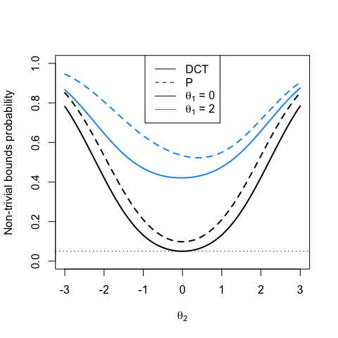

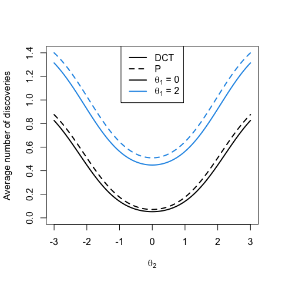

## The partitioning procedure with Dunnett’s local tests for many-to-one comparisons

To illustrate this approach, we consider the recovery data from Bretz et al. (2016). A company conducted a study to evaluate the effectiveness of specialized heating blankets in assisting post-surgical body heat. Four types of blankets, labeled b0, b1, b2, and b3, were tested on surgical patients to measure their impact on recovery times. The b0 blanket served as the standard option already utilized in different hospitals. The main focus was to assess the recovery time, measured in minutes, of patients randomly assigned to one of the four treatments. A shorter recovery time would indicate a more effective treatment. The key question addressed in this study is whether blanket types b1, b2, or b3 modify recovery time compared to b0. To perform a formal analysis of the data, we assume an one-way layout
$$y_{ij} =
\gamma + \mu_i + \epsilon_{ij}$$
where $\gamma + \mu_i$ represents the expected recovery time for blanket b$i$, $i=0,1,2,3$, with i.i.d. errors $\epsilon_{ij} \sim N(0,\sigma^2)$.

```r
rm(list=ls())

library(mvtnorm)
library(multcomp)
```

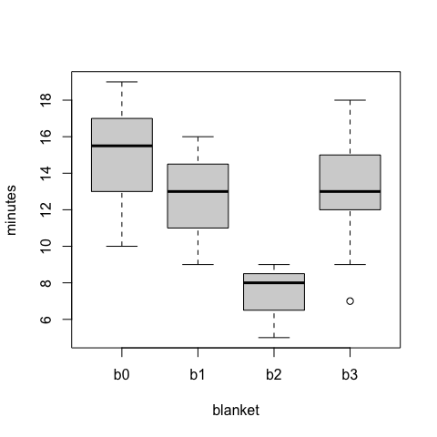

```r
data("recovery", package = "multcomp")
plot(minutes ~ blanket, data = recovery)
```

```r
fit <- aov(minutes ~ blanket, data = recovery)
sigma <- sqrt( sum(fit$residuals^2)/fit$df.residual )
```

Dunnett’s procedure is the standard procedure used to address the many-to-one comparisons problem. In the absence of specific information about the direction of the effect, we typically formulate two-sided null hypotheses of the form $H_i: \theta_i = 0$, where $\theta_i = \mu_i - \mu_0$ and $i=1,2,3$.

```r
set.seed(123)
# Dunnett two-sided single step
dun_twosided <- glht(fit,
                  linfct = mcp(blanket = "Dunnett"),
                  alternative = "two.sided")
summary(dun_twosided)
```

```
#>
#>   Simultaneous Tests for General Linear Hypotheses
#>
#> Multiple Comparisons of Means: Dunnett Contrasts
#>
#>
#> Fit: aov(formula = minutes ~ blanket, data = recovery)
#>
#> Linear Hypotheses:
#>              Estimate Std. Error t value Pr(>|t|)
#> b1 - b0 == 0  -2.1333     1.6038  -1.330    0.456
#> b2 - b0 == 0  -7.4667     1.6038  -4.656   <0.001 ***
#> b3 - b0 == 0  -1.6667     0.8848  -1.884    0.182
#> ---
#> Signif. codes:  0 '***' 0.001 '**' 0.01 '*' 0.05 '.' 0.1 ' ' 1
#> (Adjusted p values reported -- single-step method)
```

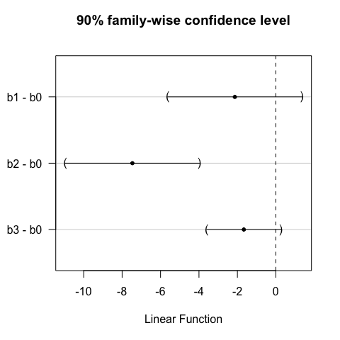

```r
plot(confint(dun_twosided, level=0.9))
```

Step-down Dunnett procedure for two-sided hypotheses. Although the step-down Dunnett procedure is more powerful, the single-step Dunnett’s procedure provides simultaneous confidence intervals.

```r
# Dunnett two-sided step-down
summary(dun_twosided, test = adjusted(type = "free"))
```

```
#>
#>   Simultaneous Tests for General Linear Hypotheses
#>
#> Multiple Comparisons of Means: Dunnett Contrasts
#>
#>
#> Fit: aov(formula = minutes ~ blanket, data = recovery)
#>
#> Linear Hypotheses:
#>              Estimate Std. Error t value Pr(>|t|)
#> b1 - b0 == 0  -2.1333     1.6038  -1.330  0.19160
#> b2 - b0 == 0  -7.4667     1.6038  -4.656  0.00012 ***
#> b3 - b0 == 0  -1.6667     0.8848  -1.884  0.12729
#> ---
#> Signif. codes:  0 '***' 0.001 '**' 0.01 '*' 0.05 '.' 0.1 ' ' 1
#> (Adjusted p values reported -- free method)
```

Dunnett’s local test for the orthant hypothesis $J_K: \{\bigcap_{i \in K} K_i\} \cap \{\bigcap_{i \notin K}H^-_i\}$ is given by
$$\psi_{K} = 1\{ \max(\{\hat{\theta}_i, i\in
K^c \}\cup \{-\hat{\theta}_j, j\in K \}) > c_{\alpha}(K)
\}$$
where $\hat{\theta}_i$ is the estimate of $\theta_i$ and $c_{\alpha}( K)$ represents the $(1-\alpha)$-quantile of the maximum of an $n$-variate $t$ distribution with a correlation matrix that has off-diagonal elements whose sign depends on $K$.

For example, the Dunnett’s local test for the orthant hypothesis $J_K$ with $K=\{1,2\}$:

```r
# Contrast matrix
contr <- rbind("b1 -b0" = c(-1, 1, 0, 0),
               "b2 -b0" = c(-1, 0, 1, 0),
               "b3 -b0" = c(1, 0, 0, -1))
# Index set K
as.numeric(which(contr[,1]==-1))
```

```
#> [1] 1 2
```

```r
RES <- summary(glht(fit, linfct = mcp(blanket = contr),alternative = "less"))
# P-value
min(RES$test$pvalues)
```

```
#> [1] 6.055887e-05
```

```r
# Correlation matrix
VC <- RES$lin %*% RES$vcov %*% t(RES$lin)
D <- diag(1/sqrt(diag(VC)))
COR <- D %*% VC %*% D
COR
```

```
#>            [,1]       [,2]       [,3]
#> [1,]  1.0000000  0.1304348 -0.2364331
#> [2,]  0.1304348  1.0000000 -0.2364331
#> [3,] -0.2364331 -0.2364331  1.0000000
```

```r
# Critical value
alpha = 0.1
qmvt(1-alpha, corr = COR, df = RES$df, tail = "lower.tail")$quantile
```

```
#> [1] 1.873676
```

```r
# Test statistic
max(-RES$test$tstat)
```

```
#> [1] 4.655648
```

The partitioning procedure with Dunnett’s local tests:

[output not shown]

Adjusted $p$-values for base hypotheses:

| Hypothesis | Adjusted p-value | Hypothesis | Adjusted p-value |
| --- | --- | --- | --- |
| H1- | 0.996 | K1 | 0.259 |
| H2- | 0.996 | K2 | 0 |
| H3- | 0.996 | K3 | 0.098 |